# Corruption in the lab

Fedor Anna, Mokos Judit

19/12/2018

# Description of the experiment

Sequential dyadic die-rolling task  
Two-by-two design:

- Game: simple game or charity game
- Partner: simulated honest partner or simulated dishonest partner

Participants are randomly assigned to one of the four conditions:

- SH: simple game with honest partner
- SD: simple game with dishonest partner
- CH: charity game with honest partner
- CD: charity game with dishonest partner

Each participant plays 20 rounds of the game. A round of game consists of the following steps:

1. Participant learns the reported number of the supposed partner
2. Participant throws a dice
3. Participant reports the number
4. Both players get a score according to the reported numbers: the score is the reported value, if they reported a double; otherwise it’s 0
5. In the charity game a charity foundation gets a small amount of donation

# Dummy data

Data frame column names (each row is a dice roll):

- ID: random ID of participant (10000:99999)
- Game: simple or charity (S/C)
- Partner: honest or dishonest (H/D)
- Condition: one of the four experimental conditions (SH, SD, CH, CD)
- Index: index of round of game (1:20)
- ValueA: value of simulated dice roll (1:6)
- ValueB: value of participant’s reported dice roll (1:6)
- Double: whether the participant reported a double (1/0)
- Q1: answer to first questionnaire quiestion (a random letter)
- Q2: answer to second questionnaire question (a random letter)
- Fingerratio: ratio of two fingers (normal distribution, mean=1, sd=0.1)
- Saliva: ??? (normal distribution, mean=3, sd=1)

# Data checking

- Check if every participant had 20 rounds
  - Delete participants who had less than 20 rounds
  - Delete excess rounds for each participant
- Check if there is any missing data (columns)

# Figures

## Scatter plots of individual behavior

These should be based on Weisel & Shalvi, 2015, Fig. S10.  
One plot per participant. Plots from the same condition should be compiled into one composite figure.

```
##  subject's ID: 33895
```

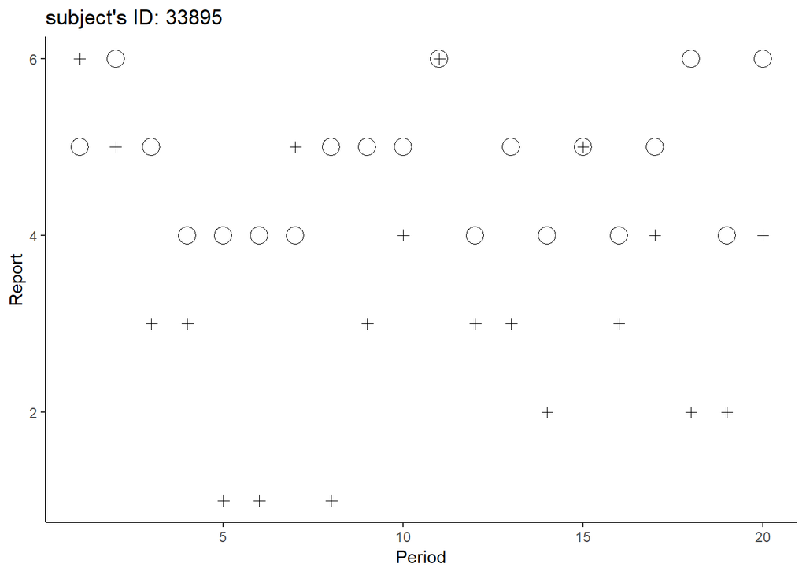

```
##
##  subject's ID: 43490
```

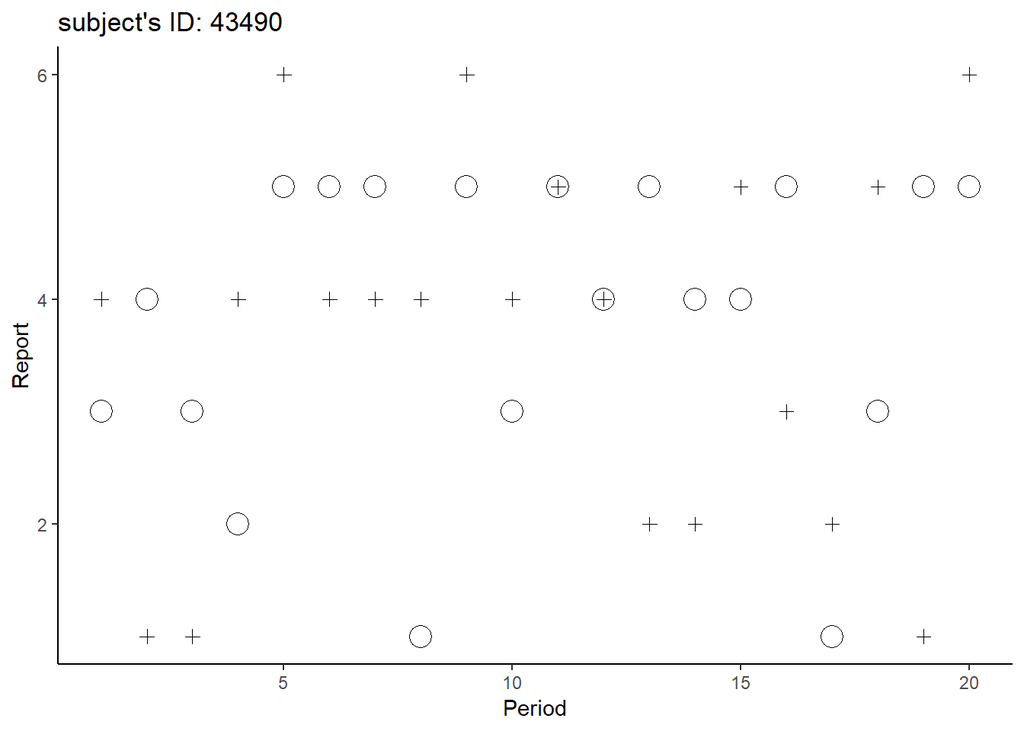

```
##
##  subject's ID: 61555
```

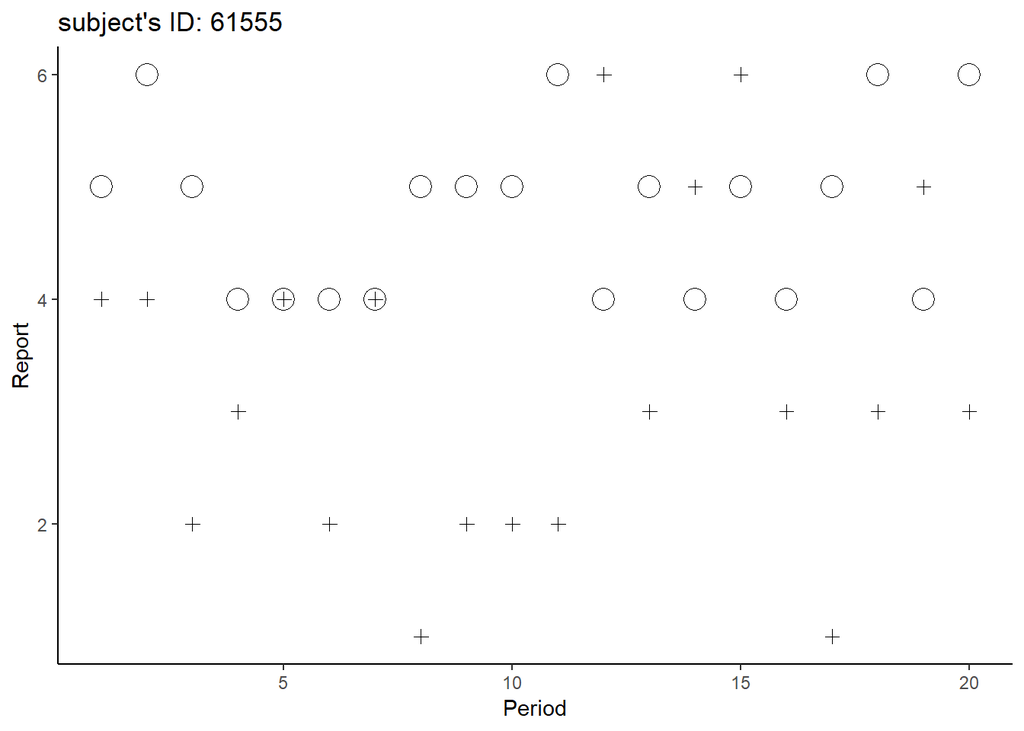

```
##
##  subject's ID: 91735
```

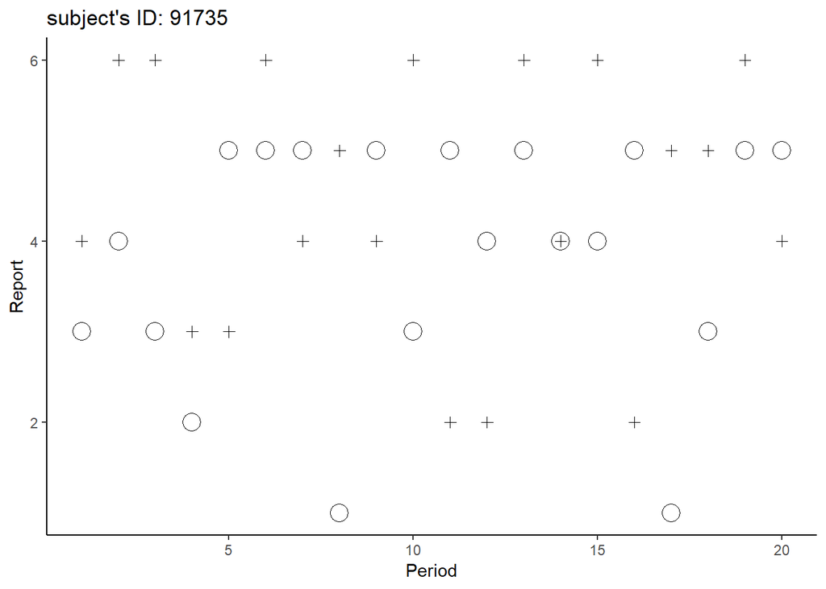

```
##
##  subject's ID: 28150
```

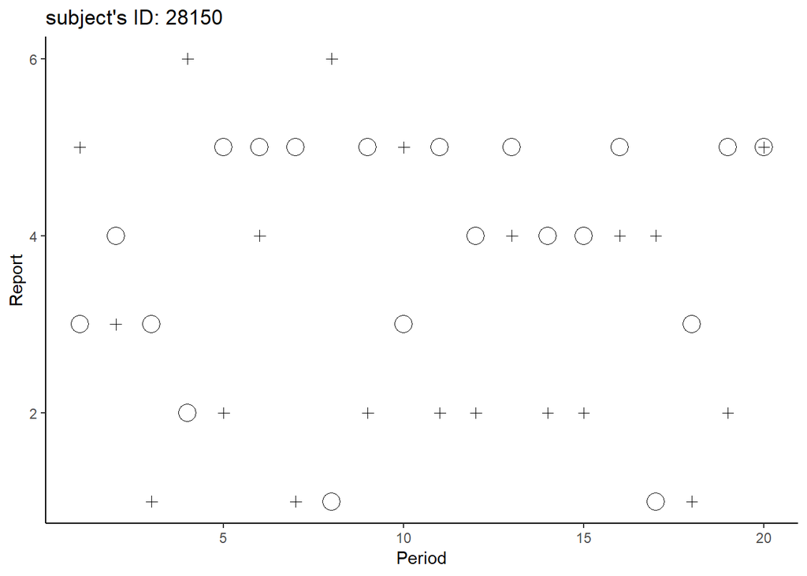

```
##
##  subject's ID: 90850
```

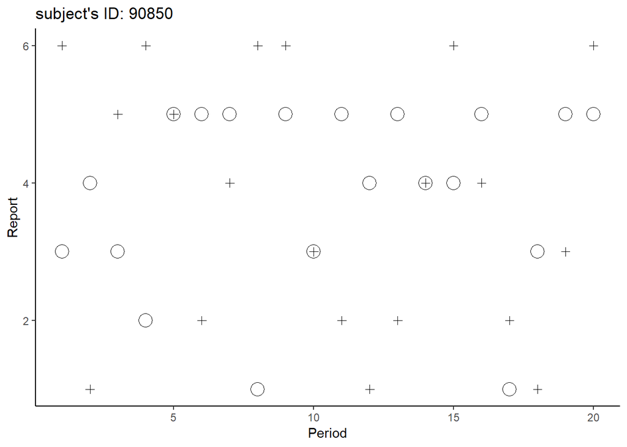

```
##
##  subject's ID: 95015
```

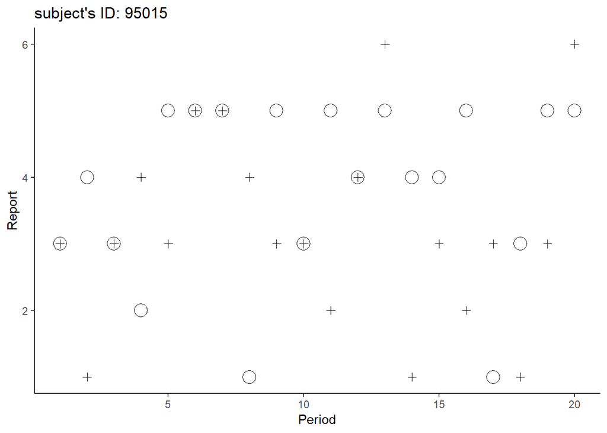

```
##
##  subject's ID: 69467
```

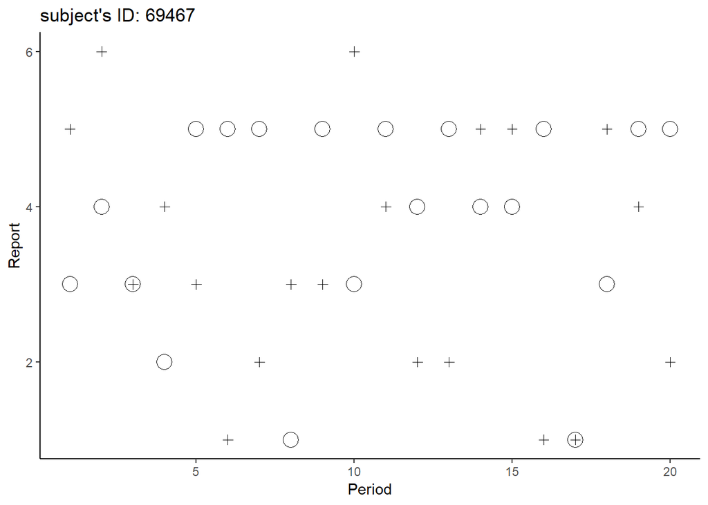

```
##
##  subject's ID: 66615
```

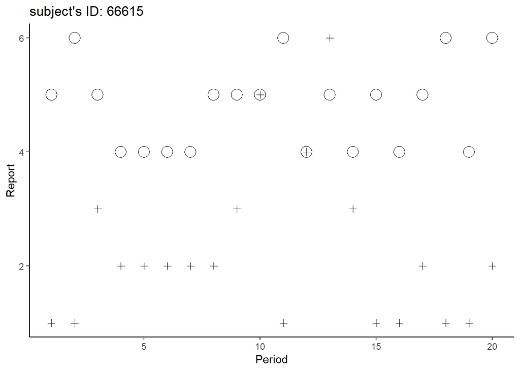

```
##
##  subject's ID: 15560
```

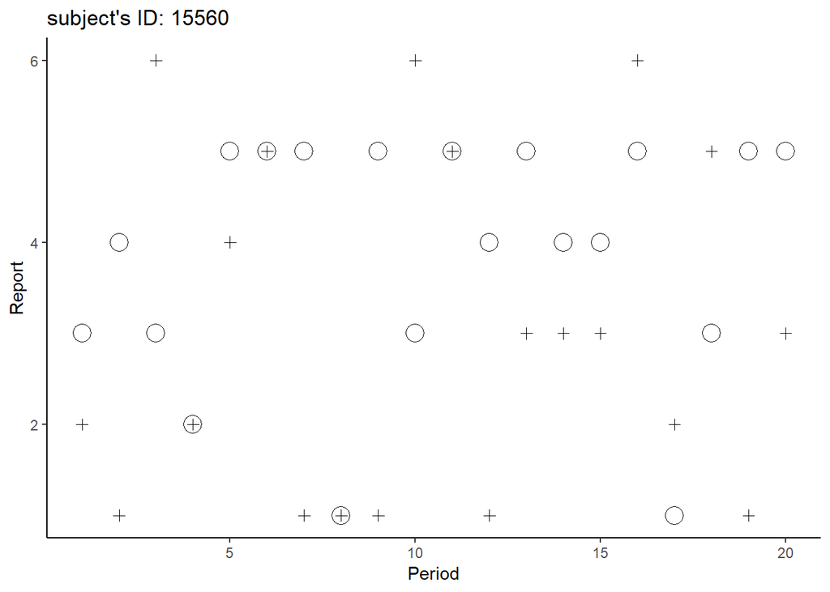

## Heat map to demonstrate the distribution of reported numbers

Like Weisel & Shalvi, 2015, Fig. 2, but instead of circles, each rectangle should be color coded according the number of observations within them.  
One figure per condition.

```
##
##  Condition: SD
```

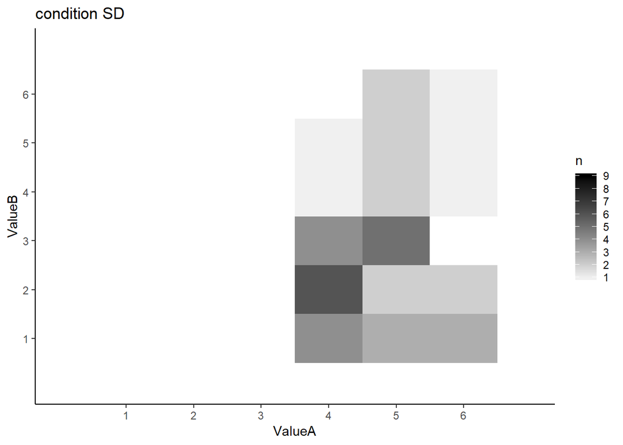

```
##
##
##  Condition: SH
```

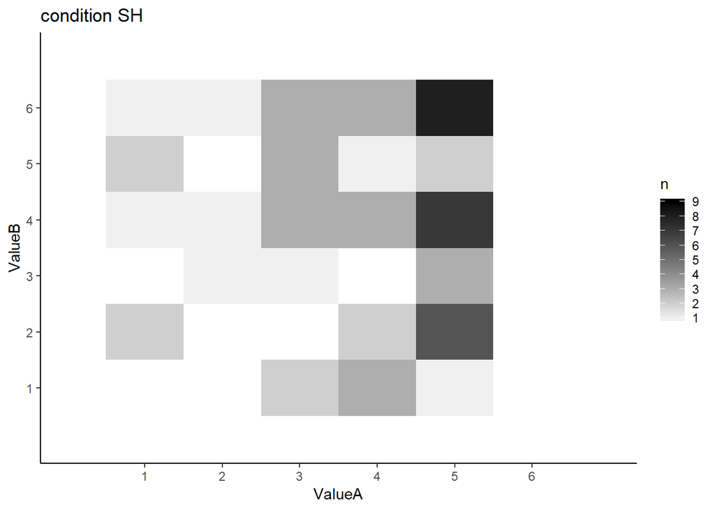

```
##
##
##  Condition: CD
```

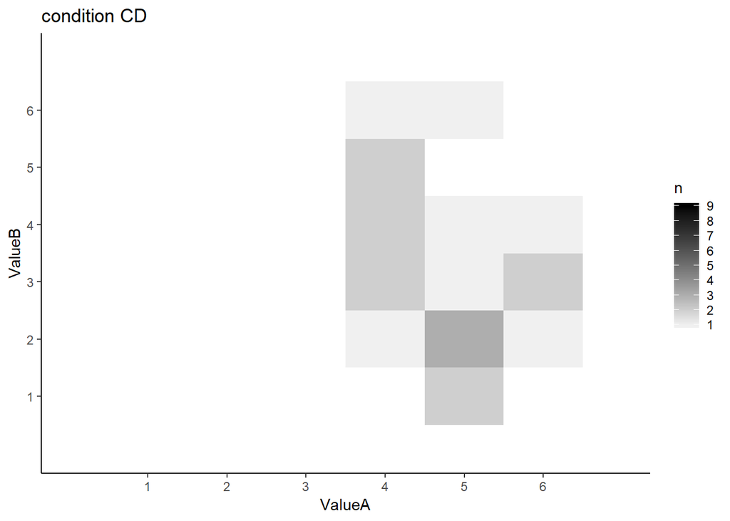

```
##
##
##  Condition: CH
```

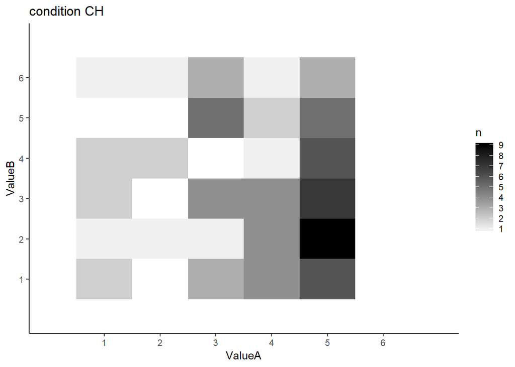

## Box plots of the mean number of doubles

One box for each condition on the same figure  
(Mean reports: does not make sense in our case, because player A is simulated)

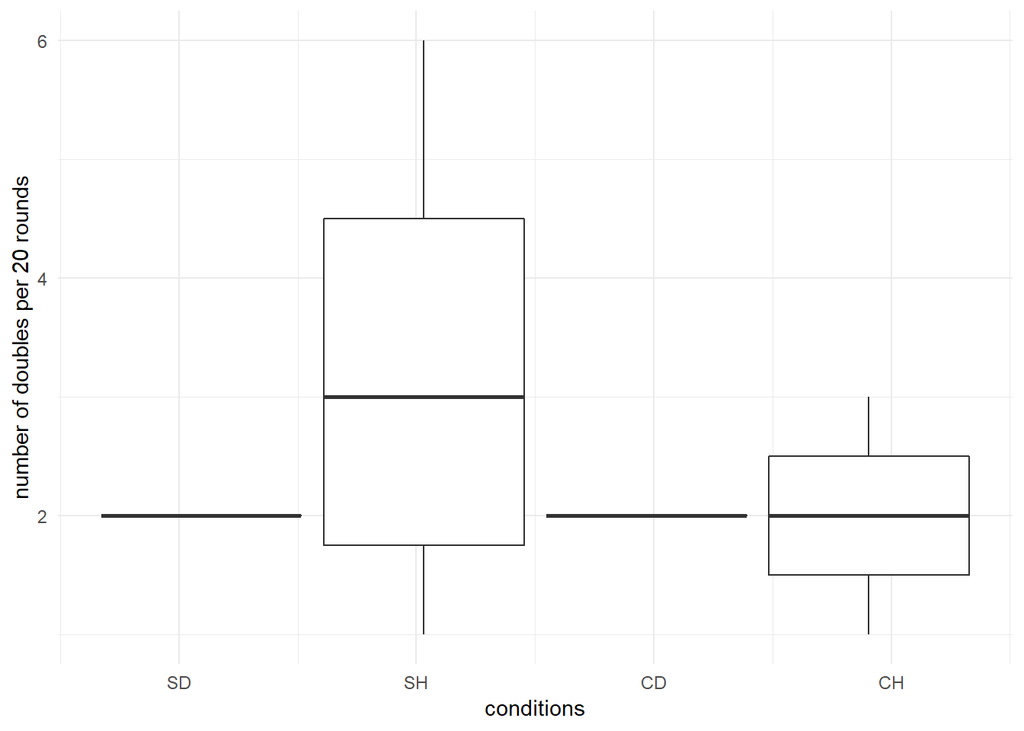

# Statistics

## Summary of data

Summary of groups and participants:

[output not shown]

| ID | Condition | Nbof_doubles | Avg_report |
| --- | --- | --- | --- |
| 15560 | CH | 4 | 3.05 |
| 28150 | CH | 1 | 3.15 |
| 33895 | SD | 2 | 3.30 |
| 43490 | SH | 2 | 3.65 |
| 61555 | CD | 2 | 3.25 |
| 66615 | SD | 2 | 2.25 |

## Distribution of reported numbers

Our null hypothesis is that the reported values come from a uniform distribution, i.e. numbers from 1 to 6 are reported with the same probability, since we used a fair dice. Our alternative hypothesis is that participants cheat and report doubles in order to inflate their profit.

This would lead to skewed distributions when the participant playes with a dishonest simulated partner who reports larger numbers with higher probability. In case of an honest simulated partner, whose dice throw values were sampled from a uniform distribution, we expect that the participants’ reported values also come from a uniform ditribution (although it is possible that participants try to signal to their supposed partners to cheat by occassionally reporting 6s, but we do not expect this to create a significant difference).

We used chi-square goodness of fit tests to test whether the reported values come from a uniform distribution, separately for each condition.

| condition | df | chi.square | p_value |
| --- | --- | --- | --- |
| SD | NA | 8.3 | 0.15 |
| SH | NA | 10.6 | 0.06 |
| CD | NA | 3.4 | 0.70 |
| CH | NA | 3.7 | 0.59 |

```
##
##  Two-sample Kolmogorov-Smirnov test
##
## data:  group_SH$ValueB and fairdice_det
## D = 0.15, p-value = 0.586
## alternative hypothesis: two-sided
```

```
##
##  Two-sample Kolmogorov-Smirnov test
##
## data:  group_SD$ValueB and fairdice_det
## D^+ = 0.225, p-value = 0.1098
## alternative hypothesis: the CDF of x lies above that of y
```

```
##
##  Two-sample Kolmogorov-Smirnov test
##
## data:  group_CH$ValueB and fairdice_det
## D = 0.1, p-value = 0.9251
## alternative hypothesis: two-sided
```

```
##
##  Two-sample Kolmogorov-Smirnov test
##
## data:  group_CD$ValueB and fairdice_det
## D^+ = 0.13333, p-value = 0.6053
## alternative hypothesis: the CDF of x lies above that of y
```

We also made qqplots:

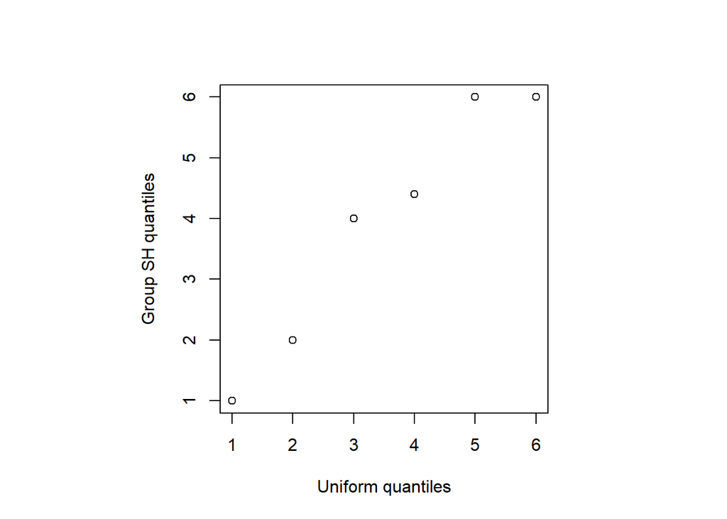

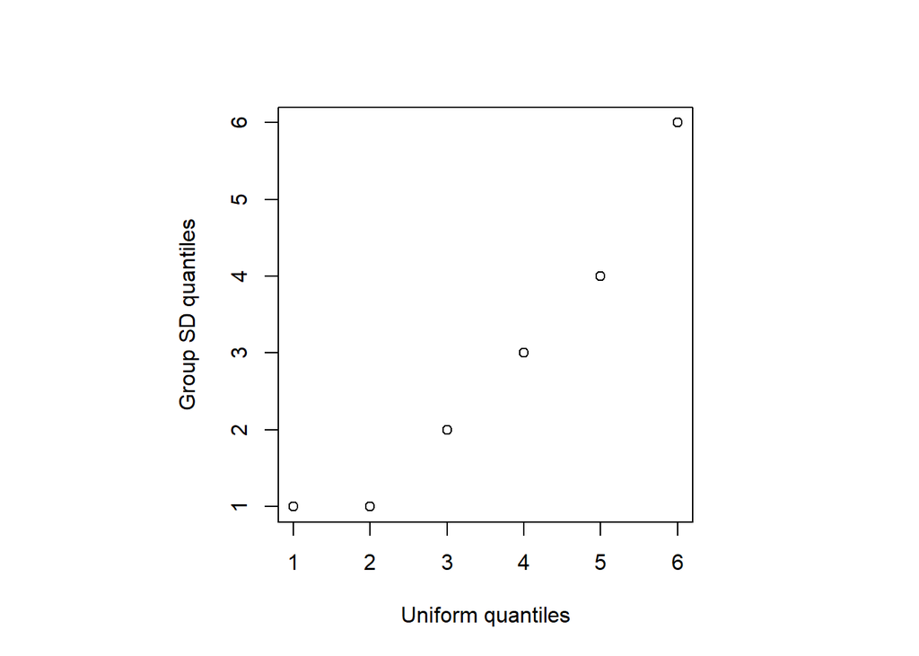

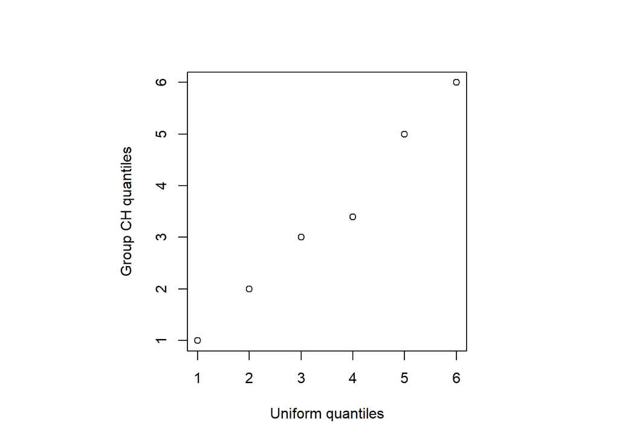

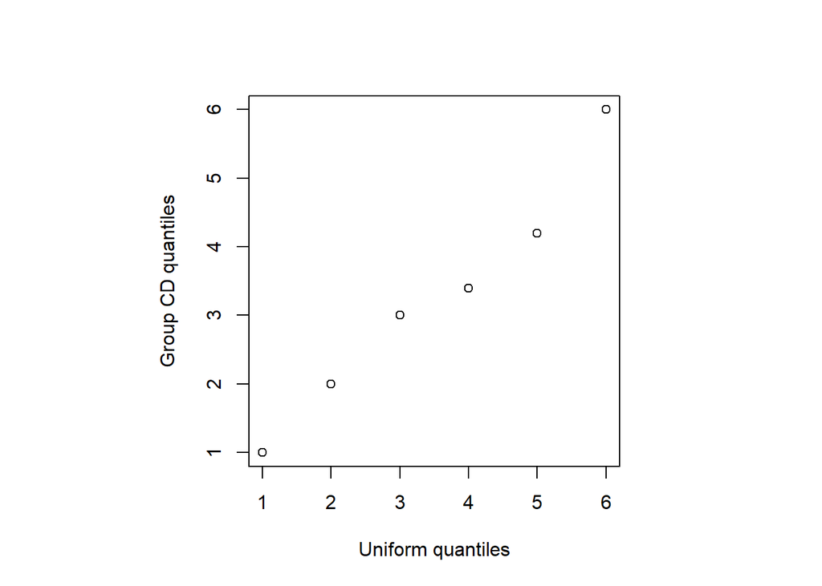

## The number of doubles

Ultimately, participants must report doubles, thus match their reported values to that of player A, in order to increase their payoff. The chi-square test cannot detect cheating in those groups where player A is “honest”, even if player B cheats on each and every round, because the distribution of reported values would still come from a uniform distribution. Testing the mean of the reported numbers against an expected value of 3.5 does not make sense for the same reasons. Therefore, we also tested, whether the number of doubles is higher than its expected value of 3.33 (the probability of throwing a double is 1/6; the expected number of doubles in 20 rounds is 20*1/6 = 3.33 in case of a fair dice and honest player).

Each participant (“dyad”) is a single observation: the number of reported doubles  
Wilcoxon signed-rank U test, separately for each condition  
Expected value: 3.33 doubles/20 trials (16.7%; 20*1/6)

```
## [1] "CD"
##
##  Wilcoxon rank sum test
##
## data:  current$Nbof_doubles and 3.33
## W = 0, p-value = 1
## alternative hypothesis: true location shift is greater than 0
##
## [1] "CH"
##
##  Wilcoxon rank sum test
##
## data:  current$Nbof_doubles and 3.33
## W = 2, p-value = 0.6
## alternative hypothesis: true location shift is greater than 0
##
## [1] "SD"
##
##  Wilcoxon rank sum test with continuity correction
##
## data:  current$Nbof_doubles and 3.33
## W = 0, p-value = 0.9831
## alternative hypothesis: true location shift is greater than 0
##
## [1] "SH"
##
##  Wilcoxon rank sum test
##
## data:  current$Nbof_doubles and 3.33
## W = 0, p-value = 1
## alternative hypothesis: true location shift is greater than 0
```

## Compare the number of doubles in pairs of conditions

Mann-Whitney U test (or two-sample Wilcoxon test), one-sided.

## Effect size (ANNA)

To estimate the effect size of the honest-dishonest treatment let’s compare the choices of participant Bs, who were paired with an honest A vs. a cheating A.  
Data: from the supplementary material of Weisel&Shalvy, 2015 and from Wouda et al., 2015  
The number of doubles in each condition against the hypothetical expected value: Wilcoxon signed-rank U test expected value = 3.33 maximum value when cheating = 20

Compare the number of doubles in pairs of conditions: Wilcoxon signed-rank U test

Monte Carlo method One can simulate the distribution you think the two samples come from many thousands of times using Monte Carlo methods. The percentage of those samples the Wilcoxon test correctly identifies as “different” is the power of the test. For example, if you generated 10,000 different simulated paired samples that match your actual data in terms of size and the distribution they came from, and 8,000 of them are correctly identified by the test as different, your power = 0.80.

## Linear regression to test the effect of predictors (JUDIT)

Dependent variable: number of reported doubles (interval)  
Predictors: game (binary), partner (binary), fingerratio (interval), hormone levels (interval)